# Modern Data Mining, HW 2

Group Member 1

Group Member 2

Group Member 3

Due: 11:59 PM, Sunday, 02/22

# 1 Case study 1: Self-esteem

Self-esteem generally describes a person’s overall sense of self-worthiness and personal value. It can play significant role in one’s motivation and success throughout the life. Factors that influence self-esteem can be inner thinking, health condition, age, life experiences etc. We will try to identify possible factors in our data that are related to the level of self-esteem.

In the well-cited National Longitudinal Study of Youth (NLSY79), it follows about 13,000 individuals and numerous individual-year information has been gathered through surveys. The survey data is open to public [here](https://www.nlsinfo.org/investigator/). Among many variables we assembled a subset of variables including personal demographic variables in different years, household environment in 79, ASVAB test Scores in 81 and Self-Esteem scores in 81 and 87 respectively.

The data is store in `NLSY79.csv`.

Here are the description of variables:

**Personal Demographic Variables**

- Gender: a factor with levels “female” and “male”
- Education05: years of education completed by 2005
- HeightFeet05, HeightInch05: height measurement. For example, a person of 5’10 will be recorded as HeightFeet05=5, HeightInch05=10.
- Weight05: weight in lbs.
- Income87, Income05: total annual income from wages and salary in 2005.
- Job87 (missing), Job05: job type in 1987 and 2005, including Protective Service Occupations, Food Preparation and Serving Related Occupations, Cleaning and Building Service Occupations, Entertainment Attendants and Related Workers, Funeral Related Occupations, Personal Care and Service Workers, Sales and Related Workers, Office and Administrative Support Workers, Farming, Fishing and Forestry Occupations, Construction Trade and Extraction Workers, Installation, Maintenance and Repairs Workers, Production and Operating Workers, Food Preparation Occupations, Setters, Operators and Tenders, Transportation and Material Moving Workers

**Household Environment**

- Imagazine: a variable taking on the value 1 if anyone in the respondent’s household regularly read magazines in 1979, otherwise 0
- Inewspaper: a variable taking on the value 1 if anyone in the respondent’s household regularly read newspapers in 1979, otherwise 0
- Ilibrary: a variable taking on the value 1 if anyone in the respondent’s household had a library card in 1979, otherwise 0
- MotherEd: mother’s years of education
- FatherEd: father’s years of education
- FamilyIncome78

**Variables Related to ASVAB test Scores in 1981**

| Test | Description |
| --- | --- |
| AFQT | percentile score on the AFQT intelligence test in 1981 |
| Coding | score on the Coding Speed test in 1981 |
| Auto | score on the Automotive and Shop test in 1981 |
| Mechanic | score on the Mechanic test in 1981 |
| Elec | score on the Electronics Information test in 1981 |
| Science | score on the General Science test in 1981 |
| Math | score on the Math test in 1981 |
| Arith | score on the Arithmetic Reasoning test in 1981 |
| Word | score on the Word Knowledge Test in 1981 |
| Parag | score on the Paragraph Comprehension test in 1981 |
| Numer | score on the Numerical Operations test in 1981 |

**Self-Esteem test 81 and 87**

We have two sets of self-esteem test, one in 1981 and the other in 1987. Each set has same 10 questions. They are labeled as `Esteem81` and `Esteem87` respectively followed by the question number. For example, `Esteem81_1` is Esteem question 1 in 81.

The following 10 questions are answered as 1: strongly agree, 2: agree, 3: disagree, 4: strongly disagree

- Esteem 1: “I am a person of worth”
- Esteem 2: “I have a number of good qualities”
- Esteem 3: “I am inclined to feel like a failure”
- Esteem 4: “I do things as well as others”
- Esteem 5: “I do not have much to be proud of”
- Esteem 6: “I take a positive attitude towards myself and others”
- Esteem 7: “I am satisfied with myself”
- Esteem 8: “I wish I could have more respect for myself”
- Esteem 9: “I feel useless at times”
- Esteem 10: “I think I am no good at all”

## 1.1 Data preparation

Load the data. Do a quick EDA to get familiar with the data set. Pay attention to the unit of each variable. Are there any missing values?

```
## 'data.frame':    2431 obs. of  46 variables:
##  $ Subject       : int  2 6 7 8 9 13 16 17 18 20 ...
##  $ Gender        : chr  "female" "male" "male" "female" ...
##  $ Education05   : int  12 16 12 14 14 16 13 13 13 17 ...
##  $ Income87      : int  16000 18000 0 9000 15000 2200 27000 20000 28000 27000 ...
##  $ Job05         : chr  "4700 TO 4960: Sales and Related Workers" "10 TO 430: Executive, Administrative and Managerial Occupations" "7900 TO 8960: Setters, Operators and Tenders" "5000 TO 5930: Office and Administrative Support Workers" ...
##  $ Income05      : int  5500 65000 19000 36000 65000 8000 71000 43000 120000 64000 ...
##  $ Weight05      : int  160 187 175 246 180 235 160 188 173 130 ...
##  $ HeightFeet05  : int  5 5 5 5 5 6 5 5 5 5 ...
##  $ HeightInch05  : int  2 5 9 3 6 0 4 10 9 4 ...
##  $ Imagazine     : int  1 0 1 1 1 1 1 1 1 1 ...
##  $ Inewspaper    : int  1 1 1 1 1 1 1 1 1 1 ...
##  $ Ilibrary      : int  1 1 1 1 1 1 1 1 1 1 ...
##  $ MotherEd      : int  5 12 12 9 12 12 12 12 12 12 ...
##  $ FatherEd      : int  8 12 12 6 10 16 12 15 16 18 ...
```

[output cut: 32 more lines]

```
## [1] FALSE
```

```
##     Subject         Gender           Education05      Income87
##  Min.   :    2   Length:2431        Min.   : 6.0   Min.   :   -2
##  1st Qu.: 1592   Class :character   1st Qu.:12.0   1st Qu.: 4500
##  Median : 3137   Mode  :character   Median :13.0   Median :12000
##  Mean   : 3504                      Mean   :13.9   Mean   :13399
##  3rd Qu.: 4668                      3rd Qu.:16.0   3rd Qu.:19000
##  Max.   :12140                      Max.   :20.0   Max.   :59387
##     Job05              Income05         Weight05    HeightFeet05
##  Length:2431        Min.   :    63   Min.   : 81   Min.   :-4.00
##  Class :character   1st Qu.: 22650   1st Qu.:150   1st Qu.: 5.00
##  Mode  :character   Median : 38500   Median :180   Median : 5.00
##                     Mean   : 49415   Mean   :183   Mean   : 5.18
##                     3rd Qu.: 61350   3rd Qu.:209   3rd Qu.: 5.00
##                     Max.   :703637   Max.   :380   Max.   : 8.00
##   HeightInch05     Imagazine       Inewspaper       Ilibrary       MotherEd
##  Min.   : 0.00   Min.   :0.000   Min.   :0.000   Min.   :0.00   Min.   : 0.0
##  1st Qu.: 2.00   1st Qu.:0.000   1st Qu.:1.000   1st Qu.:1.00   1st Qu.:11.0
##  Median : 5.00   Median :1.000   Median :1.000   Median :1.00   Median :12.0
##  Mean   : 5.32   Mean   :0.718   Mean   :0.861   Mean   :0.77   Mean   :11.7
##  3rd Qu.: 8.00   3rd Qu.:1.000   3rd Qu.:1.000   3rd Qu.:1.00   3rd Qu.:12.0
##  Max.   :11.00   Max.   :1.000   Max.   :1.000   Max.   :1.00   Max.   :20.0
##     FatherEd    FamilyIncome78     Science         Arith           Word
##  Min.   : 0.0   Min.   :    0   Min.   : 0.0   Min.   : 0.0   Min.   : 0.0
##  1st Qu.:10.0   1st Qu.:11167   1st Qu.:13.0   1st Qu.:13.0   1st Qu.:23.0
##  Median :12.0   Median :20000   Median :17.0   Median :19.0   Median :28.0
##  Mean   :11.9   Mean   :21252   Mean   :16.3   Mean   :18.6   Mean   :26.6
##  3rd Qu.:14.0   3rd Qu.:27500   3rd Qu.:20.0   3rd Qu.:25.0   3rd Qu.:32.0
##  Max.   :20.0   Max.   :75001   Max.   :25.0   Max.   :30.0   Max.   :35.0
##      Parag          Number         Coding          Auto           Math
##  Min.   : 0.0   Min.   : 0.0   Min.   : 0.0   Min.   : 0.0   Min.   : 0.0
##  1st Qu.:10.0   1st Qu.:29.0   1st Qu.:38.0   1st Qu.:10.0   1st Qu.: 9.0
##  Median :12.0   Median :36.0   Median :48.0   Median :14.0   Median :14.0
##  Mean   :11.2   Mean   :35.5   Mean   :47.1   Mean   :14.3   Mean   :14.3
##  3rd Qu.:14.0   3rd Qu.:44.0   3rd Qu.:57.0   3rd Qu.:18.0   3rd Qu.:20.0
##  Max.   :15.0   Max.   :50.0   Max.   :84.0   Max.   :25.0   Max.   :25.0
##     Mechanic         Elec           AFQT         Esteem81_1     Esteem81_2
##  Min.   : 0.0   Min.   : 0.0   Min.   :  0.0   Min.   :1.00   Min.   :1.00
##  1st Qu.:11.0   1st Qu.: 9.0   1st Qu.: 31.9   1st Qu.:1.00   1st Qu.:1.00
##  Median :14.0   Median :12.0   Median : 57.0   Median :1.00   Median :1.00
##  Mean   :14.4   Mean   :11.6   Mean   : 54.7   Mean   :1.42   Mean   :1.42
```

[output cut: 15 more lines]

```
##  Max.   :4.00   Max.   :4.00   Max.   :4.0   Max.   :4.00   Max.   :4.0
##    Esteem87_3     Esteem87_4    Esteem87_5     Esteem87_6     Esteem87_7
##  Min.   :1.00   Min.   :1.0   Min.   :1.00   Min.   :1.00   Min.   :1.00
##  1st Qu.:3.00   1st Qu.:1.0   1st Qu.:3.00   1st Qu.:1.00   1st Qu.:1.00
##  Median :4.00   Median :1.0   Median :4.00   Median :2.00   Median :2.00
##  Mean   :3.58   Mean   :1.5   Mean   :3.53   Mean   :1.59   Mean   :1.72
##  3rd Qu.:4.00   3rd Qu.:2.0   3rd Qu.:4.00   3rd Qu.:2.00   3rd Qu.:2.00
##  Max.   :4.00   Max.   :4.0   Max.   :4.00   Max.   :4.00   Max.   :4.00
##    Esteem87_8    Esteem87_9    Esteem87_10
##  Min.   :1.0   Min.   :1.00   Min.   :1.00
##  1st Qu.:3.0   1st Qu.:3.00   1st Qu.:3.00
##  Median :3.0   Median :3.00   Median :3.00
##  Mean   :3.1   Mean   :3.06   Mean   :3.37
##  3rd Qu.:4.0   3rd Qu.:4.00   3rd Qu.:4.00
##  Max.   :4.0   Max.   :4.00   Max.   :4.00
```

```
##  [1] ""
##  [2] "10 TO 430: Executive, Administrative and Managerial Occupations"
##  [3] "1000 TO 1240: Mathematical and Computer Scientists"
##  [4] "1300 TO 1560: Engineers, Architects, Surveyers, Engineering and Related Technicians"
##  [5] "1600 TO 1760: Physical Scientists"
##  [6] "1800 TO 1860: Social Scientists and Related Workers"
##  [7] "1900 TO 1960: Life, Physical and Social Science Technicians"
##  [8] "2000 TO 2060: Counselors, Sociala and Religious Workers"
##  [9] "2100 TO 2150: Lawyers, Judges and Legal Support Workers"
## [10] "2200 TO 2340: Teachers"
## [11] "2400 TO 2550: Education, Training and Library Workers"
## [12] "2600 TO 2760: Entertainers and Performers, Sports and Related Workers"
## [13] "2800 TO 2960: Media and Communications Workers"
## [14] "3000 TO 3260: Health Diagnosing and Treating Practitioners"
## [15] "3300 TO 3650: Health Care Technical and Support Occupations"
```

[output cut: 16 more lines]

```
##
##
##                                                                                  56
##                     10 TO 430: Executive, Administrative and Managerial Occupations
##                                                                                 377
##                                  1000 TO 1240: Mathematical and Computer Scientists
##                                                                                  64
## 1300 TO 1560: Engineers, Architects, Surveyers, Engineering and Related Technicians
##                                                                                  53
##                                                   1600 TO 1760: Physical Scientists
##                                                                                   4
##                                 1800 TO 1860: Social Scientists and Related Workers
##                                                                                   6
##                         1900 TO 1960: Life, Physical and Social Science Technicians
##                                                                                   7
##                             2000 TO 2060: Counselors, Sociala and Religious Workers
##                                                                                  41
##                             2100 TO 2150: Lawyers, Judges and Legal Support Workers
##                                                                                  15
##                                                              2200 TO 2340: Teachers
##                                                                                 120
##                               2400 TO 2550: Education, Training and Library Workers
##                                                                                  29
##               2600 TO 2760: Entertainers and Performers, Sports and Related Workers
##                                                                                  24
##                                      2800 TO 2960: Media and Communications Workers
##                                                                                  13
##                          3000 TO 3260: Health Diagnosing and Treating Practitioners
##                                                                                  74
##                         3300 TO 3650: Health Care Technical and Support Occupations
##                                                                                  99
##                                        3700 TO 3950: Protective Service Occupations
##                                                                                  54
##                      4000 TO 4160: Food Preparation and Serving Related Occupations
##                                                                                  68
##                             4200 TO 4250: Cleaning and Building Service Occupations
##                                                                                  67
##                          4300 TO 4430: Entertainment Attendants and Related Workers
##                                                                                  10
##                                     4500 TO 4650: Personal Care and Service Workers
```

[output cut: 8 more lines]

```
##                                                                                   9
##                             6200 TO 6940: Construction Trade and Extraction Workers
##                                                                                 135
##                         7000 TO 7620: Installation, Maintenance and Repairs Workers
##                                                                                 108
##                                      7700 TO 7750: Production and Operating Workers
##                                                                                  49
##                                          7800 TO 7850: Food Preparation Occupations
##                                                                                   4
##                                        7900 TO 8960: Setters, Operators and Tenders
##                                                                                 112
##                            9000 TO 9750: Transportation and Material Moving Workers
##                                                                                 117
##                                                                    9990: Uncodeable
##                                                                                   1
```

## 1.2 Self esteem evaluation

**Let concentrate on Esteem scores evaluated in 87.**

0. First do a quick summary over all the `Esteem` variables. Pay attention to missing values, any peculiar numbers etc. How do you fix problems discovered if there is any? Briefly describe what you have done for the data preparation.

```
##    Min. 1st Qu.  Median    Mean 3rd Qu.    Max.
##    1.00    1.00    1.00    1.38    2.00    4.00
```

```
## [1] FALSE
```

```
##    Min. 1st Qu.  Median    Mean 3rd Qu.    Max.
##     1.0     1.0     1.0     1.4     2.0     4.0
```

```
## [1] FALSE
```

```
##    Min. 1st Qu.  Median    Mean 3rd Qu.    Max.
##    1.00    3.00    4.00    3.58    4.00    4.00
```

```
## [1] FALSE
```

```
##    Min. 1st Qu.  Median    Mean 3rd Qu.    Max.
##     1.0     1.0     1.0     1.5     2.0     4.0
```

```
## [1] FALSE
```

```
##    Min. 1st Qu.  Median    Mean 3rd Qu.    Max.
##    1.00    3.00    4.00    3.53    4.00    4.00
```

```
## [1] FALSE
```

```
##    Min. 1st Qu.  Median    Mean 3rd Qu.    Max.
##    1.00    1.00    2.00    1.59    2.00    4.00
```

```
## [1] FALSE
```

```
##    Min. 1st Qu.  Median    Mean 3rd Qu.    Max.
##    1.00    1.00    2.00    1.72    2.00    4.00
```

```
## [1] FALSE
```

```
##    Min. 1st Qu.  Median    Mean 3rd Qu.    Max.
##     1.0     3.0     3.0     3.1     4.0     4.0
```

```
## [1] FALSE
```

```
##    Min. 1st Qu.  Median    Mean 3rd Qu.    Max.
##    1.00    3.00    3.00    3.06    4.00    4.00
```

```
## [1] FALSE
```

```
##    Min. 1st Qu.  Median    Mean 3rd Qu.    Max.
##    1.00    3.00    3.00    3.37    4.00    4.00
```

```
## [1] FALSE
```

The first thing I did was create a summary of all the data to provide basic insights into the distribution of the Esteem_87 scores. After this I checked for missing values (of which there are none) and exmined the intepretation of the scores more carefully. From this, I understood that there were some questions which were framed in such a way that higher scores indicated higher levels of self-esteem, and other questions which were framed in such a way that lower score indicated higher self-esteem. This needs to be standardised across all the questions to ensure easy comparison across the different questions in Esteem_87.

1. Please note that higher scores on Esteem questions 1, 2, 4, 6, and 7 indicate higher self-esteem, whereas higher scores on the remaining questions suggest lower self-esteem. To maintain consistency, consider reversing the scores of certain Esteem questions. For example, if the esteem data is stored in `data.esteem`, you can use the code `data.esteem[, c(1, 2, 4, 6, 7)] <- 5 - data.esteem[, c(1, 2, 4, 6, 7)]` to invert the scores.

To fix this, I identified questions which were framed in a positive way (Questions 1, 2, 4, 6 and 7). This meant that lower scores (“Strongly Agree”) indicated higher self-esteem. I inverted these scores, creating a standardised measure where higher scores across all questions indicated higher self-esteem.

2. Write a brief summary with necessary plots about the 10 esteem measurements.

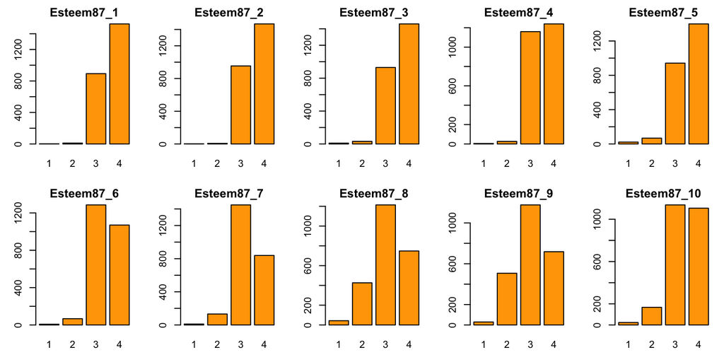

3. Do esteem scores all positively correlated? Report the pairwise correlation table and write a brief summary.

```
##             Esteem87_1 Esteem87_2 Esteem87_3 Esteem87_4 Esteem87_5 Esteem87_6
## Esteem87_1       1.000      0.704      0.448      0.528      0.399      0.464
## Esteem87_2       0.704      1.000      0.443      0.551      0.402      0.481
## Esteem87_3       0.448      0.443      1.000      0.408      0.549      0.410
## Esteem87_4       0.528      0.551      0.408      1.000      0.381      0.509
## Esteem87_5       0.399      0.402      0.549      0.381      1.000      0.405
## Esteem87_6       0.464      0.481      0.410      0.509      0.405      1.000
## Esteem87_7       0.379      0.410      0.343      0.422      0.370      0.600
## Esteem87_8       0.273      0.283      0.351      0.295      0.381      0.409
## Esteem87_9       0.236      0.259      0.349      0.287      0.354      0.364
## Esteem87_10      0.312      0.330      0.460      0.366      0.436      0.442
##             Esteem87_7 Esteem87_8 Esteem87_9 Esteem87_10
## Esteem87_1       0.379      0.273      0.236       0.312
## Esteem87_2       0.410      0.283      0.259       0.330
## Esteem87_3       0.343      0.351      0.349       0.460
## Esteem87_4       0.422      0.295      0.287       0.366
## Esteem87_5       0.370      0.381      0.354       0.436
## Esteem87_6       0.600      0.409      0.364       0.442
## Esteem87_7       1.000      0.389      0.352       0.390
## Esteem87_8       0.389      1.000      0.430       0.438
## Esteem87_9       0.352      0.430      1.000       0.579
## Esteem87_10      0.390      0.438      0.579       1.000
```

4. PCA on 10 esteem measurements. (centered but no scaling)
   1. Report the PC1 and PC2 loadings. Are they unit vectors? Are they orthogonal?

```
##               PC1     PC2
## Esteem87_1  0.324 -0.4452
## Esteem87_2  0.333 -0.4283
## Esteem87_3  0.322  0.0115
## Esteem87_4  0.324 -0.2877
## Esteem87_5  0.315  0.0793
## Esteem87_6  0.347 -0.0492
## Esteem87_7  0.315  0.0196
## Esteem87_8  0.280  0.3619
## Esteem87_9  0.277  0.4917
## Esteem87_10 0.318  0.3918
```

[output not shown]

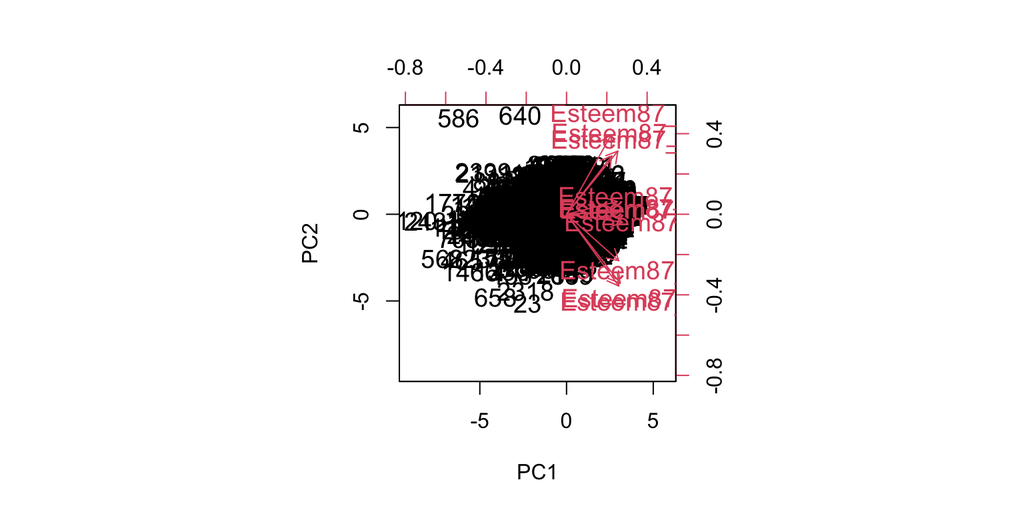

[output not shown]

5. Apply k-means to cluster subjects on the original esteem scores
   1. Find a reasonable number of clusters using within sum of squared with elbow rules.

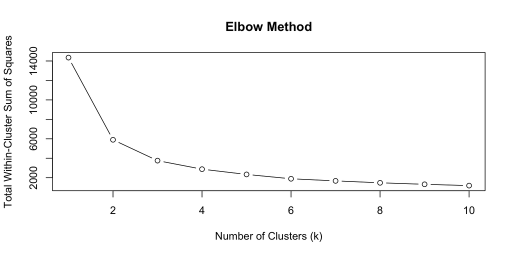

```
Looking at the Total Within-Cluster Sum of Squares, we can identify an elbow at 3 clusters

b) Can you summarize common features within each cluster?
```

```
## [1] 843 697 891
```

```
##       PC1    PC2
## 1 -2.3627  0.600
## 2 -0.0473 -1.130
## 3  2.2725  0.316
```

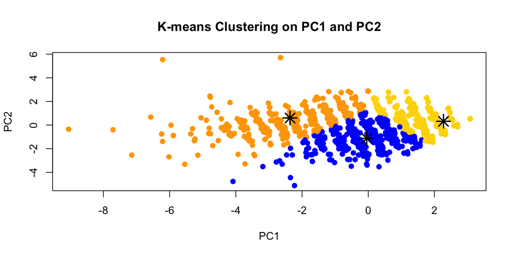

[output not shown]

```
## [1] 799 776 856
```

```
##        PC1    PC3
## 1 -0.00167 -0.704
## 2 -2.56519  0.339
## 3  2.32701  0.350
```

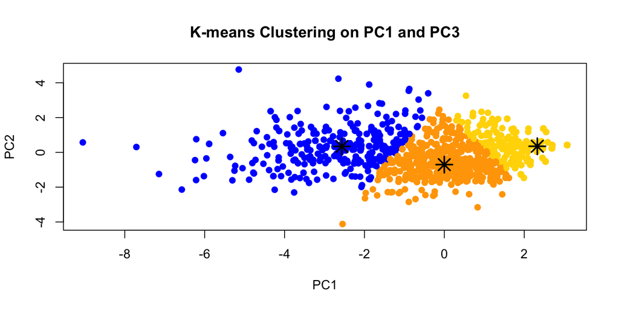

```
## [1]  605 1060  766
```

```
##      PC2      PC3
## 1  0.638 -0.98529
## 2  0.560  0.55887
## 3 -1.279  0.00482
```

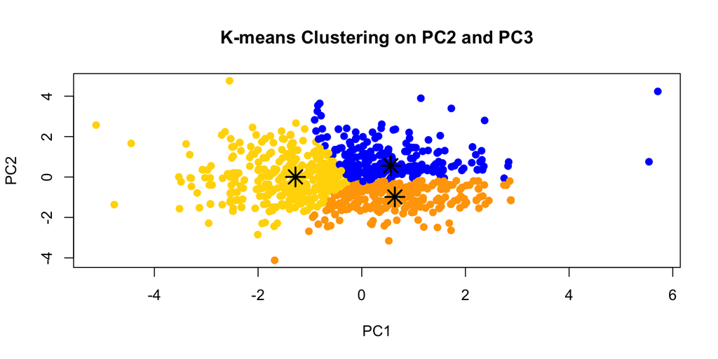

6. We now try to find out what factors are related to self-esteem? PC1 of all the Esteem scores is a good variable to summarize one’s esteem scores. We take PC1 as our response variable.
   1. Prepare possible factors/variables:

      Firstly, we have conducted PCA on the ASVAB dataset, extracting PC1 scores and adding them to the dataset as a general level of intelligence.

   Next, we will create a BMI variable to summarise an individual’s body height and weight.

   Finally, we are going to remove the unwanted variables from the dataset (specifically, Esteem81 scores, AFQT scores except for AFQT). The primary reason for this is that these variables are already described through other variables such as Intelligence or Esteem, or they are not needed (like Esteem81).

```
## 'data.frame':    2431 obs. of  15 variables:
##  $ Subject       : int  2 6 7 8 9 13 16 17 18 20 ...
##  $ Gender        : chr  "female" "male" "male" "female" ...
##  $ Education05   : int  12 16 12 14 14 16 13 13 13 17 ...
##  $ Income87      : int  16000 18000 0 9000 15000 2200 27000 20000 28000 27000 ...
##  $ Job05         : chr  "4700 TO 4960: Sales and Related Workers" "10 TO 430: Executive, Administrative and Managerial Occupations" "7900 TO 8960: Setters, Operators and Tenders" "5000 TO 5930: Office and Administrative Support Workers" ...
##  $ Income05      : int  5500 65000 19000 36000 65000 8000 71000 43000 120000 64000 ...
##  $ Imagazine     : int  1 0 1 1 1 1 1 1 1 1 ...
##  $ Inewspaper    : int  1 1 1 1 1 1 1 1 1 1 ...
##  $ Ilibrary      : int  1 1 1 1 1 1 1 1 1 1 ...
##  $ MotherEd      : int  5 12 12 9 12 12 12 12 12 12 ...
##  $ FatherEd      : int  8 12 12 6 10 16 12 15 16 18 ...
##  $ FamilyIncome78: int  20000 35000 8502 7227 17000 20000 48000 15000 4510 50000 ...
##  $ Esteem_PC1    : num  -0.54 1.4 -0.38 -0.62 3.07 ...
##  $ Intelligence  : num  -4.366 4.545 -1.603 -0.872 0.312 ...
##  $ BMI           : num  29.3 31.1 25.8 43.6 29.1 ...
```

```
Following the data preparation, we will conduct some EDA to gain a sense of the structure of the final dataset as well as the distribution of each variable.
```

```
##     Subject         Gender           Education05      Income87
##  Min.   :    2   Length:2431        Min.   : 6.0   Min.   :   -2
##  1st Qu.: 1592   Class :character   1st Qu.:12.0   1st Qu.: 4500
##  Median : 3137   Mode  :character   Median :13.0   Median :12000
##  Mean   : 3504                      Mean   :13.9   Mean   :13399
##  3rd Qu.: 4668                      3rd Qu.:16.0   3rd Qu.:19000
##  Max.   :12140                      Max.   :20.0   Max.   :59387
##     Job05              Income05        Imagazine       Inewspaper
##  Length:2431        Min.   :    63   Min.   :0.000   Min.   :0.000
##  Class :character   1st Qu.: 22650   1st Qu.:0.000   1st Qu.:1.000
##  Mode  :character   Median : 38500   Median :1.000   Median :1.000
##                     Mean   : 49415   Mean   :0.718   Mean   :0.861
##                     3rd Qu.: 61350   3rd Qu.:1.000   3rd Qu.:1.000
##                     Max.   :703637   Max.   :1.000   Max.   :1.000
##     Ilibrary       MotherEd       FatherEd    FamilyIncome78    Esteem_PC1
##  Min.   :0.00   Min.   : 0.0   Min.   : 0.0   Min.   :    0   Min.   :-9.0499
##  1st Qu.:1.00   1st Qu.:11.0   1st Qu.:10.0   1st Qu.:11167   1st Qu.:-1.8806
##  Median :1.00   Median :12.0   Median :12.0   Median :20000   Median : 0.0669
##  Mean   :0.77   Mean   :11.7   Mean   :11.9   Mean   :21252   Mean   : 0.0000
##  3rd Qu.:1.00   3rd Qu.:12.0   3rd Qu.:14.0   3rd Qu.:27500   3rd Qu.: 1.9200
##  Max.   :1.00   Max.   :20.0   Max.   :20.0   Max.   :75001   Max.   : 3.0734
##   Intelligence         BMI
##  Min.   :-9.667   Min.   : 11.9
##  1st Qu.:-1.849   1st Qu.: 24.1
##  Median : 0.342   Median : 27.3
##  Mean   : 0.000   Mean   : 28.1
##  3rd Qu.: 2.120   3rd Qu.: 30.9
##  Max.   : 5.026   Max.   :169.5
```

```
b)   Run a few regression models between PC1 of all the esteem scores in 87 and suitable variables listed in a). Find a final best model with your **own clearly defined criterion**.

We will conduct both a forward and backwards stepwise Multiple Linear Regression Model and choose the model which minimises MSE and maximises r-squared. Esteem_PC1 will be our            dependent variable, and the remaining factors our independent variables.

We first conduct a backward step regression model which starts with all the variables and removes the least significant, until removing more variables does not improve the performance     of the model.
```

```
##
## Call:
## lm(formula = Esteem_PC1 ~ Education05 + Income87 + Job05 + Income05 +
##     Inewspaper + Ilibrary + Intelligence, data = temp)
##
## Residuals:
##    Min     1Q Median     3Q    Max
## -8.393 -1.558  0.002  1.672  5.136
##
## Coefficients:
##                                                                                           Estimate
## (Intercept)                                                                              -2.20e+00
## Education05                                                                               7.74e-02
## Income87                                                                                  1.30e-05
## Job0510 TO 430: Executive, Administrative and Managerial Occupations                      5.42e-01
## Job051000 TO 1240: Mathematical and Computer Scientists                                   6.82e-01
## Job051300 TO 1560: Engineers, Architects, Surveyers, Engineering and Related Technicians -1.27e-01
## Job051600 TO 1760: Physical Scientists                                                   -1.52e+00
## Job051800 TO 1860: Social Scientists and Related Workers                                 -6.00e-01
## Job051900 TO 1960: Life, Physical and Social Science Technicians                          2.37e-01
## Job052000 TO 2060: Counselors, Sociala and Religious Workers                              3.12e-01
## Job052100 TO 2150: Lawyers, Judges and Legal Support Workers                              1.24e-01
## Job052200 TO 2340: Teachers                                                               4.28e-01
## Job052400 TO 2550: Education, Training and Library Workers                                4.43e-01
## Job052600 TO 2760: Entertainers and Performers, Sports and Related Workers                1.24e+00
## Job052800 TO 2960: Media and Communications Workers                                       5.16e-01
## Job053000 TO 3260: Health Diagnosing and Treating Practitioners                           6.32e-01
## Job053300 TO 3650: Health Care Technical and Support Occupations                         -1.80e-01
## Job053700 TO 3950: Protective Service Occupations                                         1.03e+00
## Job054000 TO 4160: Food Preparation and Serving Related Occupations                      -1.68e-01
## Job054200 TO 4250: Cleaning and Building Service Occupations                             -1.67e-01
## Job054300 TO 4430: Entertainment Attendants and Related Workers                          -1.14e+00
## Job054500 TO 4650: Personal Care and Service Workers                                      5.29e-01
## Job054700 TO 4960: Sales and Related Workers                                              4.31e-01
## Job05500 TO 950: Management Related Occupations                                           8.43e-01
## Job055000 TO 5930: Office and Administrative Support Workers                              4.92e-01
## Job056000 TO 6130: Farming, Fishing and Forestry Occupations                              1.36e-01
## Job056200 TO 6940: Construction Trade and Extraction Workers                              6.85e-02
## Job057000 TO 7620: Installation, Maintenance and Repairs Workers                          2.50e-01
## Job057700 TO 7750: Production and Operating Workers                                       2.51e-01
```

[output cut: 151 more lines]

```
## Job057700 TO 7750: Production and Operating Workers
## Job057800 TO 7850: Food Preparation Occupations
## Job057900 TO 8960: Setters, Operators and Tenders
## Job059000 TO 9750: Transportation and Material Moving Workers
## Job059990: Uncodeable
## Income05                                                                                 ***
## Inewspaper                                                                               *
## Ilibrary
## Intelligence                                                                             ***
## ---
## Signif. codes:  0 '***' 0.001 '**' 0.01 '*' 0.05 '.' 0.1 ' ' 1
##
## Residual standard error: 2.01 on 2394 degrees of freedom
## Multiple R-squared:  0.15,   Adjusted R-squared:  0.137
## F-statistic: 11.7 on 36 and 2394 DF,  p-value: <2e-16
```

```
## Esteem_PC1 ~ Education05 + Income87 + Job05 + Income05 + Inewspaper +
##     Ilibrary + Intelligence
```

[output not shown]

```
##
## Call:
## lm(formula = Esteem_PC1 ~ Intelligence + Income05 + Education05 +
##     Income87 + Inewspaper + Job05 + Ilibrary, data = temp)
##
## Residuals:
##    Min     1Q Median     3Q    Max
## -8.393 -1.558  0.002  1.672  5.136
##
## Coefficients:
##                                                                                           Estimate
## (Intercept)                                                                              -2.20e+00
## Intelligence                                                                              1.24e-01
## Income05                                                                                  4.61e-06
## Education05                                                                               7.74e-02
## Income87                                                                                  1.30e-05
## Inewspaper                                                                                2.99e-01
## Job0510 TO 430: Executive, Administrative and Managerial Occupations                      5.42e-01
## Job051000 TO 1240: Mathematical and Computer Scientists                                   6.82e-01
## Job051300 TO 1560: Engineers, Architects, Surveyers, Engineering and Related Technicians -1.27e-01
## Job051600 TO 1760: Physical Scientists                                                   -1.52e+00
## Job051800 TO 1860: Social Scientists and Related Workers                                 -6.00e-01
## Job051900 TO 1960: Life, Physical and Social Science Technicians                          2.37e-01
## Job052000 TO 2060: Counselors, Sociala and Religious Workers                              3.12e-01
## Job052100 TO 2150: Lawyers, Judges and Legal Support Workers                              1.24e-01
## Job052200 TO 2340: Teachers                                                               4.28e-01
## Job052400 TO 2550: Education, Training and Library Workers                                4.43e-01
## Job052600 TO 2760: Entertainers and Performers, Sports and Related Workers                1.24e+00
## Job052800 TO 2960: Media and Communications Workers                                       5.16e-01
## Job053000 TO 3260: Health Diagnosing and Treating Practitioners                           6.32e-01
## Job053300 TO 3650: Health Care Technical and Support Occupations                         -1.80e-01
## Job053700 TO 3950: Protective Service Occupations                                         1.03e+00
## Job054000 TO 4160: Food Preparation and Serving Related Occupations                      -1.68e-01
## Job054200 TO 4250: Cleaning and Building Service Occupations                             -1.67e-01
## Job054300 TO 4430: Entertainment Attendants and Related Workers                          -1.14e+00
## Job054500 TO 4650: Personal Care and Service Workers                                      5.29e-01
## Job054700 TO 4960: Sales and Related Workers                                              4.31e-01
## Job05500 TO 950: Management Related Occupations                                           8.43e-01
## Job055000 TO 5930: Office and Administrative Support Workers                              4.92e-01
## Job056000 TO 6130: Farming, Fishing and Forestry Occupations                              1.36e-01
```

[output cut: 151 more lines]

```
## Job056000 TO 6130: Farming, Fishing and Forestry Occupations
## Job056200 TO 6940: Construction Trade and Extraction Workers
## Job057000 TO 7620: Installation, Maintenance and Repairs Workers
## Job057700 TO 7750: Production and Operating Workers
## Job057800 TO 7850: Food Preparation Occupations
## Job057900 TO 8960: Setters, Operators and Tenders
## Job059000 TO 9750: Transportation and Material Moving Workers
## Job059990: Uncodeable
## Ilibrary
## ---
## Signif. codes:  0 '***' 0.001 '**' 0.01 '*' 0.05 '.' 0.1 ' ' 1
##
## Residual standard error: 2.01 on 2394 degrees of freedom
## Multiple R-squared:  0.15,   Adjusted R-squared:  0.137
## F-statistic: 11.7 on 36 and 2394 DF,  p-value: <2e-16
```

```
## Esteem_PC1 ~ Intelligence + Income05 + Education05 + Income87 +
##     Inewspaper + Job05 + Ilibrary
```

[output not shown]

```
##
## Call:
## lm(formula = best_formula, data = df_exh)
##
## Residuals:
##    Min     1Q Median     3Q    Max
## -8.910 -1.617  0.034  1.680  4.791
##
## Coefficients:
##               Estimate Std. Error t value Pr(>|t|)
## (Intercept)  -2.38e+00   3.27e-01   -7.29  4.3e-13 ***
## Education05   9.46e-02   2.08e-02    4.55  5.7e-06 ***
## Income87      1.37e-05   3.85e-06    3.56  0.00038 ***
## Income05      4.81e-06   1.00e-06    4.81  1.6e-06 ***
## Inewspaper    2.50e-01   1.29e-01    1.94  0.05193 .
## Ilibrary      1.56e-01   1.03e-01    1.52  0.12921
## MotherEd      2.65e-02   1.86e-02    1.42  0.15461
## Intelligence  1.28e-01   2.05e-02    6.21  6.2e-10 ***
## ---
## Signif. codes:  0 '***' 0.001 '**' 0.01 '*' 0.05 '.' 0.1 ' ' 1
##
## Residual standard error: 2.03 on 2423 degrees of freedom
## Multiple R-squared:  0.128,  Adjusted R-squared:  0.126
## F-statistic: 50.9 on 7 and 2423 DF,  p-value: <2e-16
```

[output not shown]

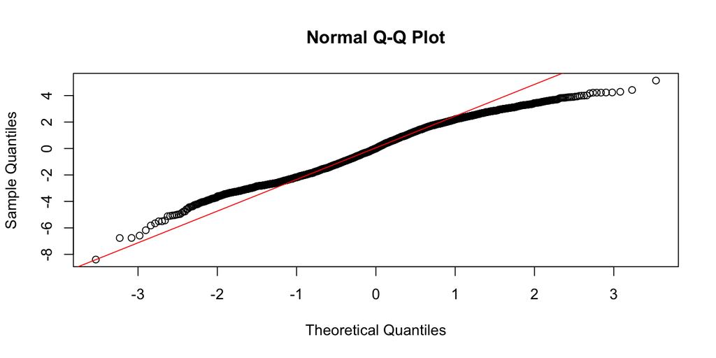

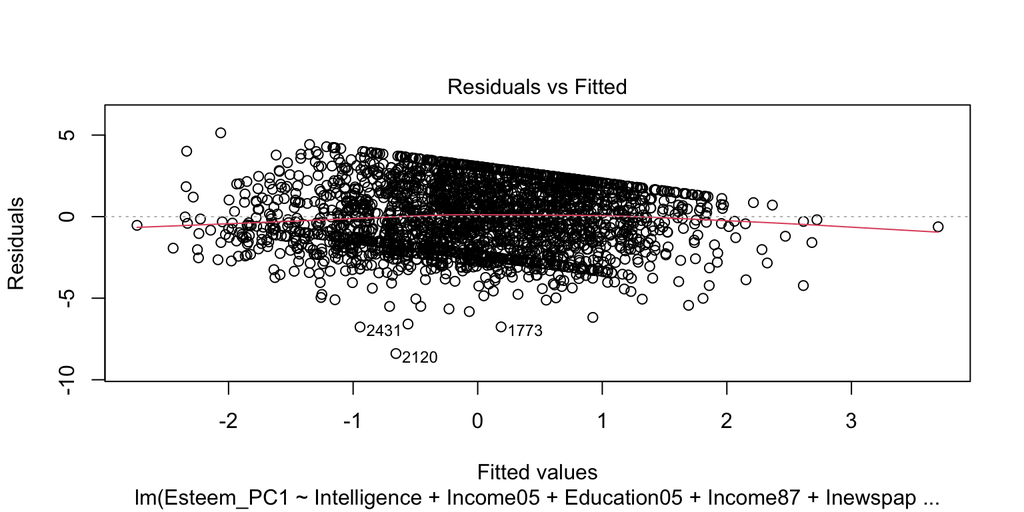

[output not shown]